# Experimental design and ANOVA examples

Author

Alex Sanchez-Pla

Published

February 15, 2023

# Example 1. A completely randomized experiment

## Description

Gene therapy experiment: compare four techniques for correcting faulty genes

- A: normal gene inserted in non-specific location
  - B: Abnormal gene swapped for a normal gene
  - C: Abnormal gene repaired through selective reverse mutation
  - D: Regulation of a particular gene altered

## Randomization

20 independent individuals are selected.

```r
mice <- paste0("m",1:20)
```

Treatments are assigned at random.

```r
randomized<- sample (mice, 20)
TREAT<-rep(LETTERS[1:4], each=5)
names(randomized) <- TREAT
```

## Data collection

Once the randomization is done, the experiment is performed and gene expression is measured on each mouse.

```r
RESP <- c(96,99,100,104,84,91,90,75,80,90,70,90,84,76,78,78,87,67,66,76)
names(RESP) <- paste(names(randomized), randomized, sep=".")
```

## Data Analysis

```r
dades<-data.frame (TREAT, RESP)
dades$TREAT <- as.factor(TREAT)

kableExtra::kable(dades) %>%  kableExtra::kable_styling(full_width=FALSE)
```

|  | TREAT | RESP |
| --- | --- | --- |
| A.m6 | A | 96 |
| A.m15 | A | 99 |
| A.m16 | A | 100 |
| A.m12 | A | 104 |
| A.m5 | A | 84 |
| B.m2 | B | 91 |
| B.m18 | B | 90 |
| B.m13 | B | 75 |
| B.m8 | B | 80 |
| B.m4 | B | 90 |
| C.m9 | C | 70 |
| C.m11 | C | 90 |
| C.m14 | C | 84 |
| C.m3 | C | 76 |
| C.m1 | C | 78 |
| D.m10 | D | 78 |
| D.m19 | D | 87 |
| D.m17 | D | 67 |
| D.m7 | D | 66 |
| D.m20 | D | 76 |

```r
model <- RESP ~ TREAT

aov1<-aov (model, data=dades)
summary(aov1)
```

```
            Df Sum Sq Mean Sq F value Pr(>F)
TREAT        3   1321   440.3   7.218 0.0028 **
Residuals   16    976    61.0
---
Signif. codes:  0 '***' 0.001 '**' 0.01 '*' 0.05 '.' 0.1 ' ' 1
```

```r
model.tables(aov1)
```

```
Tables of effects

 TREAT
TREAT
    A     B     C     D
12.55  1.15 -4.45 -9.25
```

```r
model.tables(aov1,type="means") # Mitjanes dels grups
```

```
Tables of means
Grand mean

84.05

 TREAT
TREAT
   A    B    C    D
96.6 85.2 79.6 74.8
```

```r
(hsd=TukeyHSD(aov1,which="TREAT",conf=0.95))
```

```
  Tukey multiple comparisons of means
    95% family-wise confidence level

Fit: aov(formula = model, data = dades)

$TREAT
     diff      lwr       upr     p adj
B-A -11.4 -25.5324  2.732395 0.1376990
C-A -17.0 -31.1324 -2.867605 0.0159107
D-A -21.8 -35.9324 -7.667605 0.0022116
C-B  -5.6 -19.7324  8.532395 0.6748712
D-B -10.4 -24.5324  3.732395 0.1933974
D-C  -4.8 -18.9324  9.332395 0.7670929
```

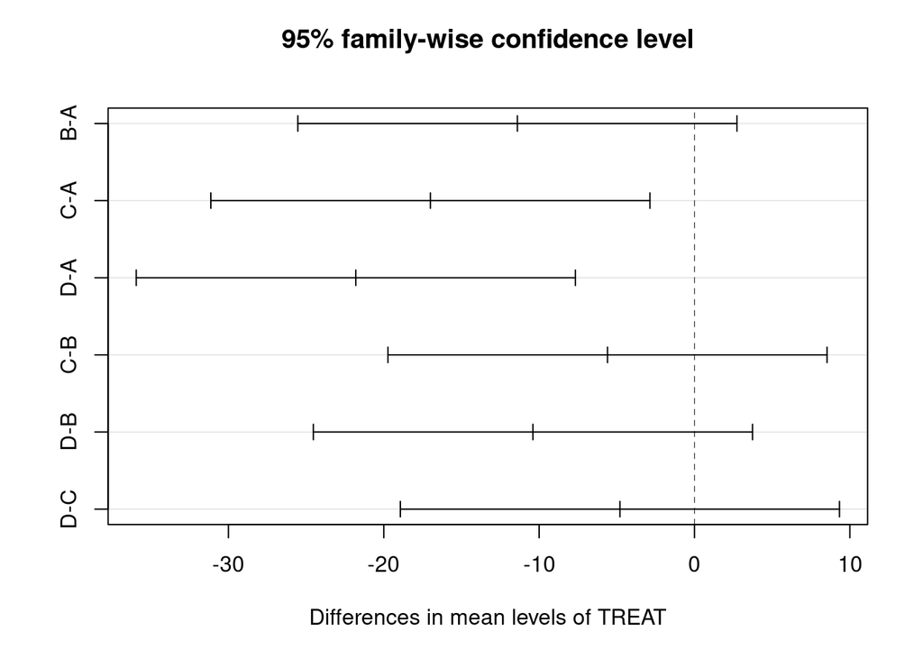

```r
plot(hsd)
```

## Model assumptions verification

ANOVA does not work under all circumstances. Some assumptions have to be true for the data:

- Homocedasticity or variance homogeneity
- Independence of errors
- Normality of errors

This can be a long process but plots are helpful to provide an overview of assumptions verification.

```r
opt<- par(mfrow=c(2,2))
plot(aov1)
```

[output not shown]

```r
par(opt)
```

## Exercises

A gene is suspected to have some connection with blood cancer. There are four stages of blood cancer: stage I, stage II, stage III, and stage IV.

For treating a patient, identiﬁcation of blood cancer is crucial in the ﬁrst three stages.

Three mRNA samples were collected from stage I, stage II, and stage III, respectively.

The experiment is repeated six times, as shown in the table.

Find whether there is any difference in mean expression values in the three mRNA samples.

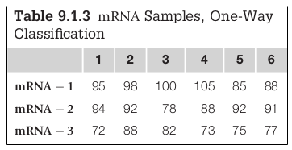

# Example 2: Randomized Block design

## Randomization

Randomization is not illustrated here. Try to find out how you can do the randomization per blocks.

```r
dades<-expand.grid(medium=1:4, Tx =1:6)
```

## Data collection

Once treatments have been randomly assigned to each culture medium the experiment is performed and the data is collected.

```r
regeneration <- c(34.98,41.22,36.94,39.97,40.89,46.69, 46.65, 41.90, 42.07, 49.42, 52.68, 42.91, 37.18, 45.85, 40.23, 39.20, 37.99, 41.99, 37.61, 40.45, 34.89, 50.15, 44.57, 43.29)
dades <-cbind(dades, regeneration)
dades$medium<-as.factor(dades$medium)
dades$Tx<-as.factor(dades$Tx)
kableExtra::kable(dades) %>%  kableExtra::kable_styling(full_width=FALSE)
```

| medium | Tx | regeneration |
| --- | --- | --- |
| 1 | 1 | 34.98 |
| 2 | 1 | 41.22 |
| 3 | 1 | 36.94 |
| 4 | 1 | 39.97 |
| 1 | 2 | 40.89 |
| 2 | 2 | 46.69 |
| 3 | 2 | 46.65 |
| 4 | 2 | 41.90 |
| 1 | 3 | 42.07 |
| 2 | 3 | 49.42 |
| 3 | 3 | 52.68 |
| 4 | 3 | 42.91 |
| 1 | 4 | 37.18 |
| 2 | 4 | 45.85 |
| 3 | 4 | 40.23 |
| 4 | 4 | 39.20 |
| 1 | 5 | 37.99 |
| 2 | 5 | 41.99 |
| 3 | 5 | 37.61 |
| 4 | 5 | 40.45 |
| 1 | 6 | 34.89 |
| 2 | 6 | 50.15 |
| 3 | 6 | 44.57 |
| 4 | 6 | 43.29 |

## Data analysis

The analysis is based on the following linear model:

```r
model.1<- regeneration ~ medium + Tx
model.1
```

```
regeneration ~ medium + Tx
```

The model is used to establish if there are any significant differences between treatments.

The differences between mediums are not relevant, because we assume they are different (that’s why we block).

```r
aov.1<-aov (model.1, data=dades)
summary(aov.1)
```

```
            Df Sum Sq Mean Sq F value  Pr(>F)
medium       3  197.0   65.67   9.120 0.00112 **
Tx           5  201.3   40.26   5.592 0.00419 **
Residuals   15  108.0    7.20
---
Signif. codes:  0 '***' 0.001 '**' 0.01 '*' 0.05 '.' 0.1 ' ' 1
```

```r
# equatiomatic::extract_eq(aov.1)
```

If we had ignored blocking, the result would have been different:

```r
model.0<- regeneration ~  Tx
aov.0<-aov (model.0, data=dades)
summary(aov.0)
```

```
            Df Sum Sq Mean Sq F value Pr(>F)
Tx           5  201.3   40.26   2.376 0.0802 .
Residuals   18  305.0   16.95
---
Signif. codes:  0 '***' 0.001 '**' 0.01 '*' 0.05 '.' 0.1 ' ' 1
```

## Assumptions

Assumptions should always be checked when using ANOVA

```r
opt<- par(mfrow=c(2,2))
plot(aov1)
```

[output not shown]

```r
par(opt)
```

## Exercise

**Effect of Atorvastatin (Lipitor) on Gene Expression in People with Vascular Disease (National Institutes of Health)**

It has been known that atherosclerosis and its consequences (coronary heart disease and stroke) are the principal causes of mortality. Gene expression proﬁling of peripheral white blood cells provides information that may be predictive about vascular risk.

Table 9.2.3 gives gene expression meassurements, classiﬁed according to age group and dose level of Atorvastatin treatment.

Test whether the dose level and age groups signiﬁcantly affect the gene expression.

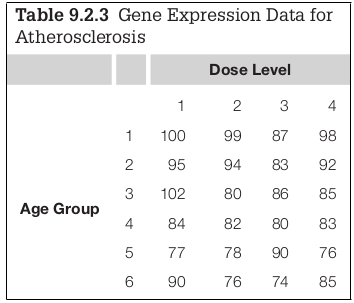

# Example 3: Factorial designs

## Randomization

We start by considering the possible combinations between all levels of Diet and Treatment.

```r
dades<-expand.grid(replica=1:5, Diet = c("Standard", "Modified"), Treatment=c("Placebo", "Drug"))
kableExtra::kable(dades) %>% kableExtra::kable_styling(full_width=FALSE)
```

| replica | Diet | Treatment |
| --- | --- | --- |
| 1 | Standard | Placebo |
| 2 | Standard | Placebo |
| 3 | Standard | Placebo |
| 4 | Standard | Placebo |
| 5 | Standard | Placebo |
| 1 | Modified | Placebo |
| 2 | Modified | Placebo |
| 3 | Modified | Placebo |
| 4 | Modified | Placebo |
| 5 | Modified | Placebo |
| 1 | Standard | Drug |
| 2 | Standard | Drug |
| 3 | Standard | Drug |
| 4 | Standard | Drug |
| 5 | Standard | Drug |
| 1 | Modified | Drug |
| 2 | Modified | Drug |
| 3 | Modified | Drug |
| 4 | Modified | Drug |
| 5 | Modified | Drug |

Participants in the study (call them i1, i2, …i20) are randomly assigned to one of the combinations.

```r
participants <- paste0("i", 1:20)
assignments <- cbind(dades, Partic=sample(participants))
kableExtra::kable(assignments) %>% kableExtra::kable_styling(full_width=FALSE)
```

| replica | Diet | Treatment | Partic |
| --- | --- | --- | --- |
| 1 | Standard | Placebo | i14 |
| 2 | Standard | Placebo | i17 |
| 3 | Standard | Placebo | i12 |
| 4 | Standard | Placebo | i6 |
| 5 | Standard | Placebo | i16 |
| 1 | Modified | Placebo | i20 |
| 2 | Modified | Placebo | i2 |
| 3 | Modified | Placebo | i10 |
| 4 | Modified | Placebo | i5 |
| 5 | Modified | Placebo | i11 |
| 1 | Standard | Drug | i7 |
| 2 | Standard | Drug | i9 |
| 3 | Standard | Drug | i8 |
| 4 | Standard | Drug | i18 |
| 5 | Standard | Drug | i4 |
| 1 | Modified | Drug | i13 |
| 2 | Modified | Drug | i3 |
| 3 | Modified | Drug | i1 |
| 4 | Modified | Drug | i19 |
| 5 | Modified | Drug | i15 |

## Data collection

Next, the experiment is done and the data can be collected

```r
WBC<-c( 2, .7, 1, 1.2, 1.3, 1.9, 1.9, 3.5, 1.2, 2.3, 2.4, 2.6, 1.9, 1.6, 1.7, 0.4, 0.2, 0.1, 0.4, 0.3)
names(WBC)<- assignments$Partic
dades <- cbind(assignments, WBC)
kableExtra::kable(dades) %>% kableExtra::kable_styling(full_width=FALSE)
```

|  | replica | Diet | Treatment | Partic | WBC |
| --- | --- | --- | --- | --- | --- |
| i14 | 1 | Standard | Placebo | i14 | 2.0 |
| i17 | 2 | Standard | Placebo | i17 | 0.7 |
| i12 | 3 | Standard | Placebo | i12 | 1.0 |
| i6 | 4 | Standard | Placebo | i6 | 1.2 |
| i16 | 5 | Standard | Placebo | i16 | 1.3 |
| i20 | 1 | Modified | Placebo | i20 | 1.9 |
| i2 | 2 | Modified | Placebo | i2 | 1.9 |
| i10 | 3 | Modified | Placebo | i10 | 3.5 |
| i5 | 4 | Modified | Placebo | i5 | 1.2 |
| i11 | 5 | Modified | Placebo | i11 | 2.3 |
| i7 | 1 | Standard | Drug | i7 | 2.4 |
| i9 | 2 | Standard | Drug | i9 | 2.6 |
| i8 | 3 | Standard | Drug | i8 | 1.9 |
| i18 | 4 | Standard | Drug | i18 | 1.6 |
| i4 | 5 | Standard | Drug | i4 | 1.7 |
| i13 | 1 | Modified | Drug | i13 | 0.4 |
| i3 | 2 | Modified | Drug | i3 | 0.2 |
| i1 | 3 | Modified | Drug | i1 | 0.1 |
| i19 | 4 | Modified | Drug | i19 | 0.4 |
| i15 | 5 | Modified | Drug | i15 | 0.3 |

## Modeling and Analysis

First, consider a model that ignores interaction between treatment and diet.

```r
model.1<- WBC ~ Diet + Treatment # this model ignores interaction
aov.1<-aov (model.1, data=dades)
summary(aov.1)
```

```
            Df Sum Sq Mean Sq F value Pr(>F)
Diet         1  0.882  0.8820   1.101  0.309
Treatment    1  1.458  1.4580   1.820  0.195
Residuals   17 13.622  0.8013
```

Now add an interaction between Diet and Treatment.

```r
model.2<- WBC ~ Diet + Treatment + Diet:Treatment
aov.2<-aov (model.2, data=dades)
summary(aov.2) # this shows that interaction had to be considered
```

```
               Df Sum Sq Mean Sq F value  Pr(>F)
Diet            1  0.882   0.882   3.039  0.1005
Treatment       1  1.458   1.458   5.023  0.0395 *
Diet:Treatment  1  8.978   8.978  30.932 4.3e-05 ***
Residuals      16  4.644   0.290
---
Signif. codes:  0 '***' 0.001 '**' 0.01 '*' 0.05 '.' 0.1 ' ' 1
```

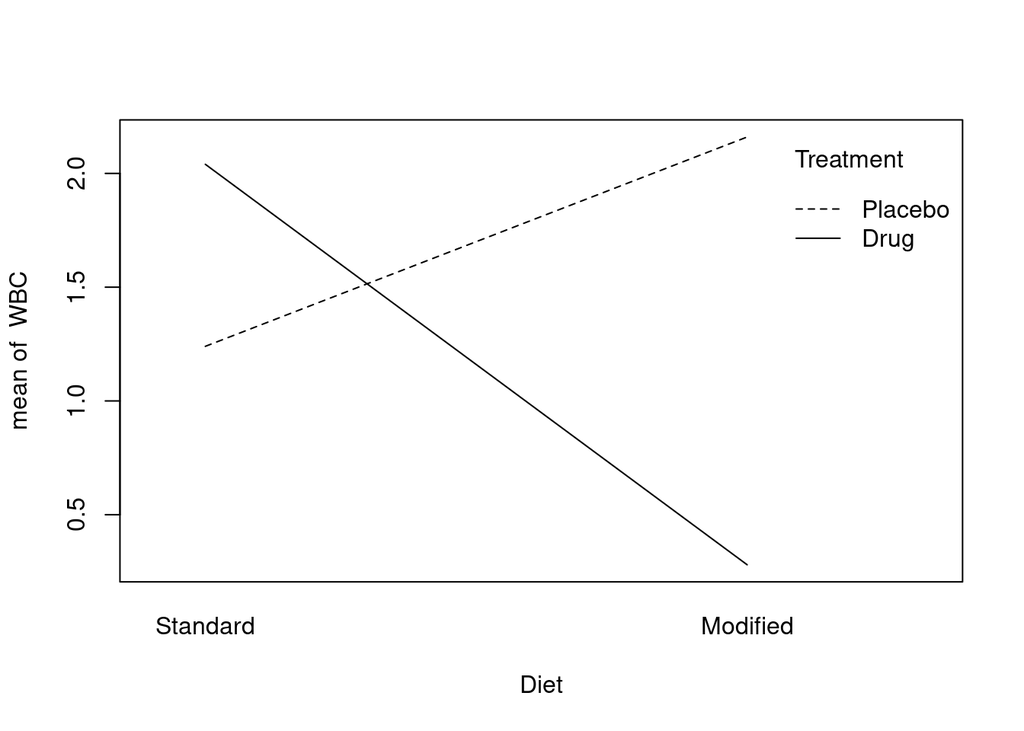

```r
with (dades, interaction.plot(Diet, Treatment, WBC))
```

## Check ANOVA model assumptions

```r
opt<- par(mfrow=c(2,2)); plot(aov1); par(opt)
```

[output not shown]